# Data Vizualization , Homework 4

Arman Manukyan

2025-03-29

Part 1: Trend Analysis (R or Python) 1. Analyse trend of goals per season. For example total goals per match, average goals per match. (Python or R) 2. Goal Distribution Per Season. Use appropriate type of graphs for goals per match, year-wise. Color- code by whether average is above or below 2.5 (over/under bet threshold). 3. Create line charts for each season. Visualize trend of goals for each team that played in that season. Highlight only Bayern Munchen with red color. Rest should be gray. Add appropriate title that will contain information about season and total scored goals. Add footnote mentioning total number of goals scored by Bayern Munchen for that season. Save all graphs in pdf.

```r
bundesliga <- read.csv("bundesliga.csv")
bundesliga2 <- read.csv("bundesliga2.csv")
bundesliga <- bundesliga %>%
  mutate(TOTAL_GOALS = FTHG + FTAG)
bundesliga
```

```
##      SEASON       LEAGUE       DATE           HOMETEAM           AWAYTEAM FTSC
## 1      1994 Bundesliga 1 1993-08-07      Bayern Munich           Freiburg  3-1
## 2      1994 Bundesliga 1 1993-08-07           Dortmund          Karlsruhe  2-1
## 3      1994 Bundesliga 1 1993-08-07           Duisburg         Leverkusen  2-2
## 4      1994 Bundesliga 1 1993-08-07            FC Koln     Kaiserslautern  0-2
## 5      1994 Bundesliga 1 1993-08-07            Hamburg           Nurnberg  5-2
## 6      1994 Bundesliga 1 1993-08-07            Leipzig            Dresden  3-3
## 7      1994 Bundesliga 1 1993-08-07         M'Gladbach      Ein Frankfurt  0-4
## 8      1994 Bundesliga 1 1993-08-07       Wattenscheid         Schalke 04  3-0
## 9      1994 Bundesliga 1 1993-08-07      Werder Bremen          Stuttgart  5-1
## 10     1994 Bundesliga 1 1993-08-14            Dresden           Duisburg  0-1
## 11     1994 Bundesliga 1 1993-08-14      Ein Frankfurt      Werder Bremen  2-2
## 12     1994 Bundesliga 1 1993-08-14           Freiburg       Wattenscheid  4-1
## 13     1994 Bundesliga 1 1993-08-14     Kaiserslautern         M'Gladbach  4-2
## 14     1994 Bundesliga 1 1993-08-14          Karlsruhe            Hamburg  2-0
```

[output cut: 15899 more lines]

```r
goals_per_season <- bundesliga %>%
  mutate(TotalGoals = FTHG + FTAG) %>%
  group_by(SEASON) %>%
  summarise(
    total_goals   = sum(TotalGoals, na.rm = TRUE),
    total_matches = n(),
    avg_goals     = mean(TotalGoals, na.rm = TRUE)
  ) %>%
  ungroup()

goals_per_season
```

```
## # A tibble: 26 × 4
##    SEASON total_goals total_matches avg_goals
##     <int>       <int>         <int>     <dbl>
##  1   1994         895           306      2.92
##  2   1995         918           306      3
##  3   1996         831           306      2.72
##  4   1997         911           306      2.98
##  5   1998         883           306      2.89
##  6   1999         866           306      2.83
##  7   2000         885           306      2.89
##  8   2001         897           306      2.93
##  9   2002         893           306      2.92
## 10   2003         821           306      2.68
## # ℹ 16 more rows
```

1.Total and Average Goals Per Season

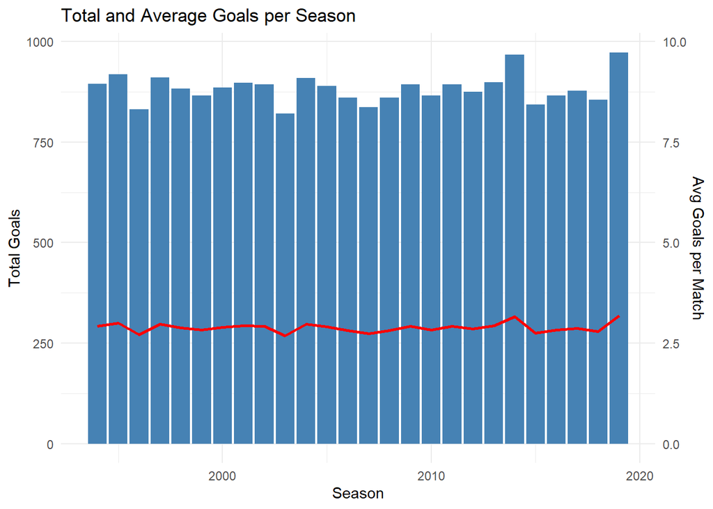

```r
goals_summary <- bundesliga %>%
  group_by(SEASON) %>%
  summarise(
    TotalGoals = sum(TOTAL_GOALS),
    Matches = n(),
    AvgGoalsPerMatch = TotalGoals / Matches
  )

ggplot(goals_summary, aes(x = SEASON)) +
  geom_col(aes(y = TotalGoals), fill = "steelblue") +
  geom_line(aes(y = AvgGoalsPerMatch * 100, group = 1), color = "red", linewidth = 1) +
  scale_y_continuous(
    name = "Total Goals",
    sec.axis = sec_axis(~ . / 100, name = "Avg Goals per Match")
  ) +
  labs(title = "Total and Average Goals per Season", x = "Season") +
  theme_minimal()
```

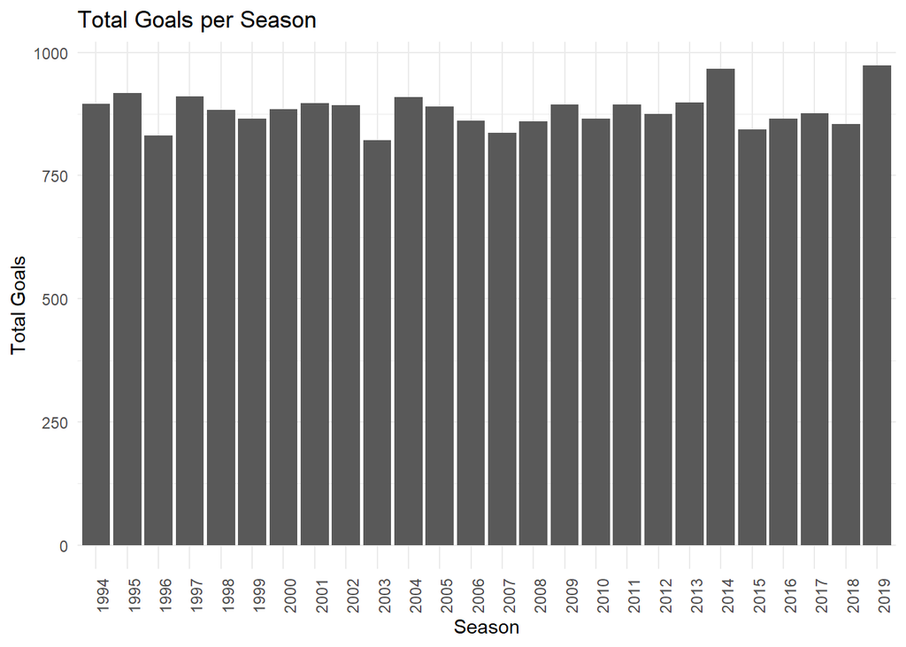

```r
ggplot(goals_per_season, aes(x = as.factor(SEASON), y = total_goals)) +
  geom_col() +
  labs(
    title = "Total Goals per Season",
    x = "Season",
    y = "Total Goals"
  ) +
  theme_minimal() +
  theme(axis.text.x = element_text(angle = 90, hjust = 1))
```

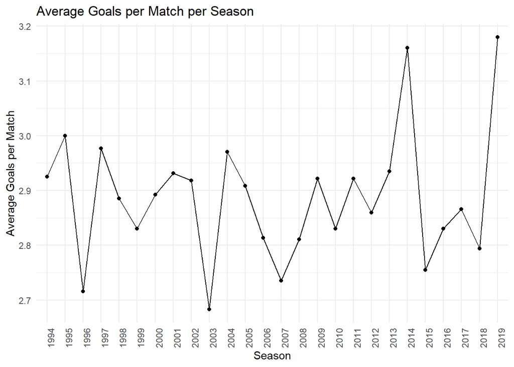

```r
ggplot(goals_per_season, aes(x = as.factor(SEASON), y = avg_goals, group = 1)) +
  geom_line() +
  geom_point() +
  labs(
    title = "Average Goals per Match per Season",
    x = "Season",
    y = "Average Goals per Match"
  ) +
  theme_minimal() +
  theme(axis.text.x = element_text(angle = 90, hjust = 1))
```

2. Goal Distribution Per Match, by Season (Over/Under 2.5 Goals)

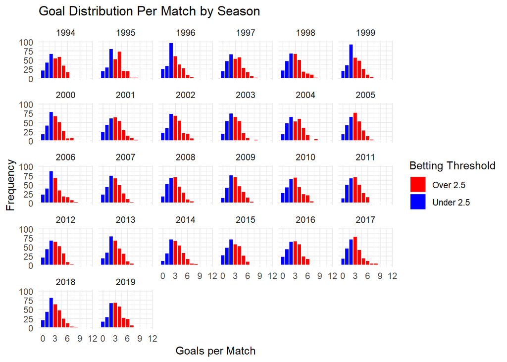

```r
goals_distribution <- bundesliga %>%
  mutate(Over_Under = ifelse(TOTAL_GOALS > 2.5, "Over 2.5", "Under 2.5"))

ggplot(goals_distribution, aes(x = TOTAL_GOALS, fill = Over_Under)) +
  geom_histogram(binwidth = 1, color = "white") +
  facet_wrap(~SEASON) +
  scale_fill_manual(values = c("red", "blue")) +
  labs(title = "Goal Distribution Per Match by Season",
       x = "Goals per Match",
       y = "Frequency",
       fill = "Betting Threshold") +
  theme_minimal()
```

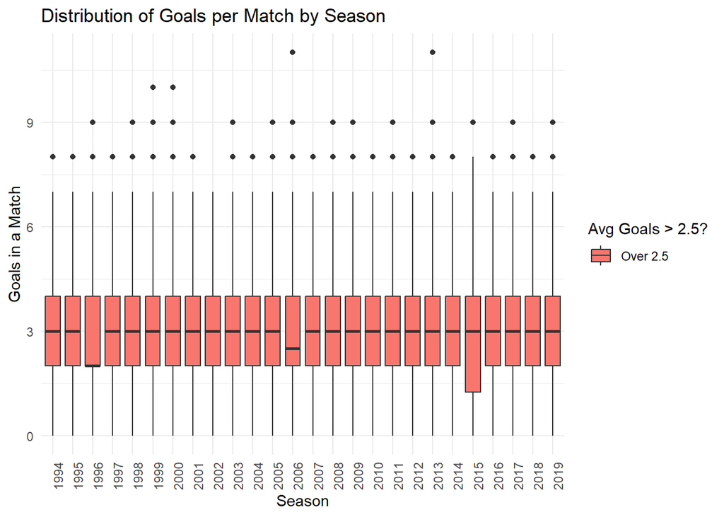

```r
bundesliga_plus <- bundesliga %>%
  mutate(TotalGoals = FTHG + FTAG) %>%
  left_join(goals_per_season %>% select(SEASON, avg_goals),
            by = "SEASON")

bundesliga_plus <- bundesliga_plus %>%
  mutate(
    over_under_indicator = ifelse(avg_goals > 2.5, "Over 2.5", "Under 2.5")
  )

ggplot(bundesliga_plus, aes(x = as.factor(SEASON), y = TotalGoals,
                            fill = over_under_indicator)) +
  geom_boxplot() +
  labs(
    title = "Distribution of Goals per Match by Season",
    x = "Season",
    y = "Goals in a Match",
    fill = "Avg Goals > 2.5?"
  ) +
  theme_minimal() +
  theme(axis.text.x = element_text(angle = 90, hjust = 1))
```

3.Team Goal Trends per Season (Highlight Bayern Munich)

```r
library(tidyverse)
library(tidyr)
team_goals <- bundesliga %>%
  pivot_longer(cols = c(HOMETEAM, AWAYTEAM), names_to = "SIDE", values_to = "TEAM") %>%
  mutate(GOALS = ifelse(SIDE == "HOMETEAM", FTHG, FTAG)) %>%
  group_by(SEASON, TEAM) %>%
  summarise(SeasonGoals = sum(GOALS), .groups = 'drop')

pdf("Team_Goals_By_Season.pdf", width = 10, height = 6) ## Save visualizations per season as a single PDF

for (s in unique(team_goals$SEASON)) {
  season_data <- filter(team_goals, SEASON == s)
  bayern_goals <- season_data %>% filter(TEAM == "Bayern Munich") %>% pull(SeasonGoals)
  total_goals <- sum(season_data$SeasonGoals)

  p <- ggplot(season_data, aes(x = reorder(TEAM, -SeasonGoals), y = SeasonGoals,
                               fill = TEAM == "Bayern Munich")) +
    geom_col(show.legend = FALSE) +
    scale_fill_manual(values = c("gray", "red")) +
    labs(
      title = paste("Team Goals in Season", s),
      subtitle = paste("Total Goals in Season:", total_goals),
      caption = paste("Bayern Munich Total Goals:", bayern_goals),
      x = "Team", y = "Goals Scored"
    ) +
    theme_minimal() +
    theme(axis.text.x = element_text(angle = 90, vjust = 0.5))

  print(p)
}

dev.off()
```

```r
bundesliga_long <- bundesliga %>%
  mutate(TotalGoalsMatch = FTHG + FTAG) %>%
  select(SEASON, DATE, HOMETEAM, AWAYTEAM, FTHG, FTAG, TotalGoalsMatch) %>%
  tidyr::pivot_longer(
    cols = c(HOMETEAM, AWAYTEAM),
    names_to = "HomeAwayFlag",
    values_to = "TEAM"
  ) %>%
  mutate(
    GoalsForThatTeam = ifelse(HomeAwayFlag == "HOMETEAM", FTHG, FTAG),
    DATE = as.Date(DATE)  # Ensure DATE is in Date format
  ) %>%
  arrange(SEASON, DATE) %>%
  group_by(SEASON, TEAM) %>%
  mutate(
    cum_goals = cumsum(GoalsForThatTeam)
  ) %>%
  ungroup()

# Step 2: Compute total goals per season (if not already available)
goals_per_season <- bundesliga %>%
  group_by(SEASON) %>%
  summarise(
    total_goals = sum(FTHG + FTAG),
    total_matches = n(),
    avg_goals = total_goals / total_matches
  )

pdf("Part1_Seasonal_Trends.pdf", width = 10, height = 6)

seasons_list <- unique(bundesliga_long$SEASON)
for(season in seasons_list){

  df_season <- bundesliga_long %>% filter(SEASON == season)

  total_goals_this_season <- goals_per_season %>%
    filter(SEASON == season) %>%
    pull(total_goals)

  bayern_goals <- df_season %>%
    filter(TEAM %in% c("Bayern Munich", "Bayern Munchen")) %>%
    slice_tail(n = 1) %>%
    pull(cum_goals)

  p <- ggplot(df_season, aes(x = DATE, y = cum_goals, group = TEAM)) +
    geom_line(color = "gray80") +
    geom_line(
      data = df_season %>% filter(TEAM %in% c("Bayern Munich", "Bayern Munchen")),
      color = "red", size = 1
    ) +
    labs(
      title = paste0("Season: ", season,
                     " | Total Goals in League: ", total_goals_this_season),
      x = "Date",
      y = "Cumulative Goals",
      caption = paste("Bayern's total goals this season:", bayern_goals)
    ) +
    theme_minimal() +
    theme(axis.text.x = element_text(angle = 90, vjust = 0.5))

  print(p)
}

dev.off()
```

Part 2: Home Advantage Deconstructed (R or Python) 1. Create Heatmap of Home vs. Away Wins per Team per Season 2. Point Differential Density: Create visualizations that will show difference per team for home and away game wins

Part 2.1: Heatmap of Home vs. Away Wins per Team per Season

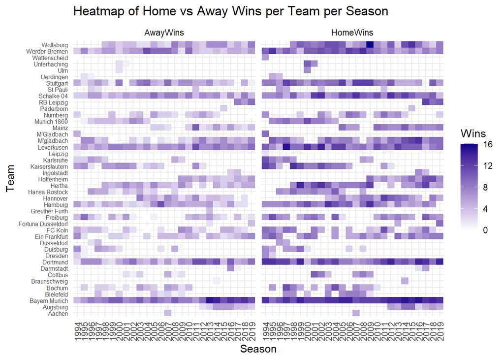

```r
home_wins <- bundesliga %>%
  filter(FTHG > FTAG) %>%
  group_by(SEASON, HOMETEAM) %>%
  summarise(HomeWins = n(), .groups = "drop") %>%
  rename(TEAM = HOMETEAM)

away_wins <- bundesliga %>%
  filter(FTAG > FTHG) %>%
  group_by(SEASON, AWAYTEAM) %>%
  summarise(AwayWins = n(), .groups = "drop") %>%
  rename(TEAM = AWAYTEAM)

win_counts <- full_join(home_wins, away_wins, by = c("SEASON", "TEAM")) %>%
  replace_na(list(HomeWins = 0, AwayWins = 0))

heatmap_data <- win_counts %>%
  pivot_longer(cols = c(HomeWins, AwayWins), names_to = "WinType", values_to = "Wins")

ggplot(heatmap_data, aes(x = factor(SEASON), y = TEAM, fill = Wins)) +
  geom_tile() +
  facet_wrap(~WinType) +
  scale_fill_gradient(low = "white", high = "darkblue") +
  labs(
    title = "Heatmap of Home vs Away Wins per Team per Season",
    x = "Season", y = "Team", fill = "Wins"
  ) +
  theme_minimal() +
  theme(
    axis.text.x = element_text(angle = 90, vjust = 0.5, hjust = 1),
    axis.text.y = element_text(size = 6)
  )
```

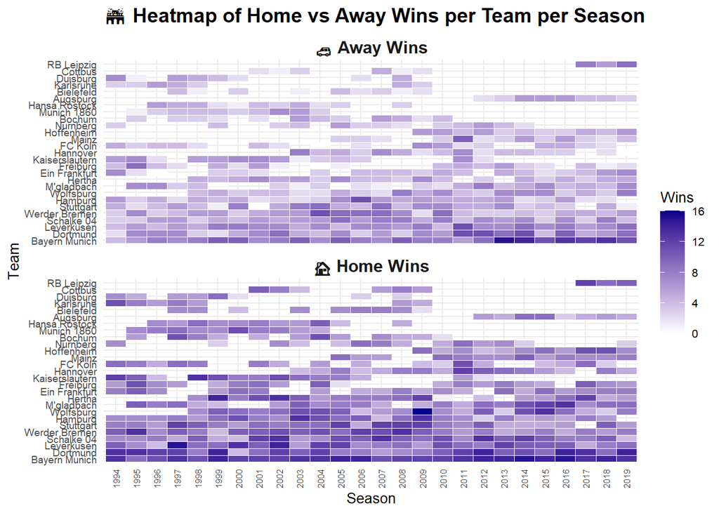

```r
library(tidyverse)


home_wins <- bundesliga %>%
  filter(FTHG > FTAG) %>%
  count(SEASON, TEAM = HOMETEAM, name = "HomeWins")


away_wins <- bundesliga %>%
  filter(FTAG > FTHG) %>%
  count(SEASON, TEAM = AWAYTEAM, name = "AwayWins")


win_counts <- full_join(home_wins, away_wins, by = c("SEASON", "TEAM")) %>%
  replace_na(list(HomeWins = 0, AwayWins = 0)) %>%
  pivot_longer(cols = c(HomeWins, AwayWins), names_to = "WinType", values_to = "Wins")


filtered_teams <- win_counts %>%
  group_by(TEAM) %>%
  summarise(total_wins = sum(Wins)) %>%
  filter(total_wins > 30) %>%
  pull(TEAM)

win_counts <- win_counts %>%
  filter(TEAM %in% filtered_teams)


team_order <- win_counts %>%
  group_by(TEAM) %>%
  summarise(total = sum(Wins)) %>%
  arrange(desc(total)) %>%
  pull(TEAM)

win_counts$TEAM <- factor(win_counts$TEAM, levels = team_order)

ggplot(win_counts, aes(x = factor(SEASON), y = TEAM, fill = Wins)) +
  geom_tile(color = "white") +
  facet_wrap(~WinType, ncol = 1, labeller = labeller(WinType = c("HomeWins" = "🏠 Home Wins", "AwayWins" = "🚗 Away Wins"))) +
  scale_fill_gradient(low = "white", high = "darkblue") +
  labs(
    title = "🏟️ Heatmap of Home vs Away Wins per Team per Season",
    x = "Season", y = "Team", fill = "Wins"
  ) +
  theme_minimal(base_size = 10) +
  theme(
    axis.text.x = element_text(angle = 90, vjust = 0.5, hjust = 1, size = 6),
    axis.text.y = element_text(size = 7),
    strip.text = element_text(size = 12, face = "bold"),
    plot.title = element_text(face = "bold", size = 14)
  )
```

Part 2.2: Point Differential Density (Home vs. Away)

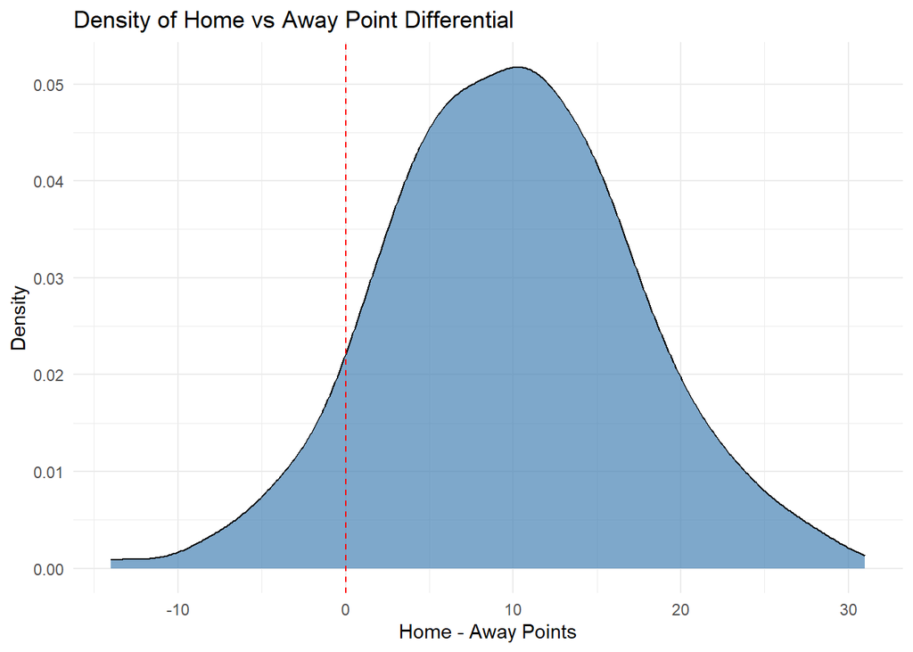

```r
bundesliga_points <- bundesliga %>%
  mutate(
    HomePoints = case_when(
      FTHG > FTAG ~ 3,
      FTHG == FTAG ~ 1,
      TRUE ~ 0
    ),
    AwayPoints = case_when(
      FTAG > FTHG ~ 3,
      FTHG == FTAG ~ 1,
      TRUE ~ 0
    )
  )

home_points <- bundesliga_points %>%
  group_by(SEASON, TEAM = HOMETEAM) %>%
  summarise(HomeTotal = sum(HomePoints), .groups = "drop")

away_points <- bundesliga_points %>%
  group_by(SEASON, TEAM = AWAYTEAM) %>%
  summarise(AwayTotal = sum(AwayPoints), .groups = "drop")

point_diff <- full_join(home_points, away_points, by = c("SEASON", "TEAM")) %>%
  replace_na(list(HomeTotal = 0, AwayTotal = 0)) %>%
  mutate(PointDiff = HomeTotal - AwayTotal)

ggplot(point_diff, aes(x = PointDiff)) +
  geom_density(fill = "steelblue", alpha = 0.7) +
  geom_vline(xintercept = 0, linetype = "dashed", color = "red") +
  labs(
    title = "Density of Home vs Away Point Differential",
    x = "Home - Away Points",
    y = "Density"
  ) +
  theme_minimal()
```

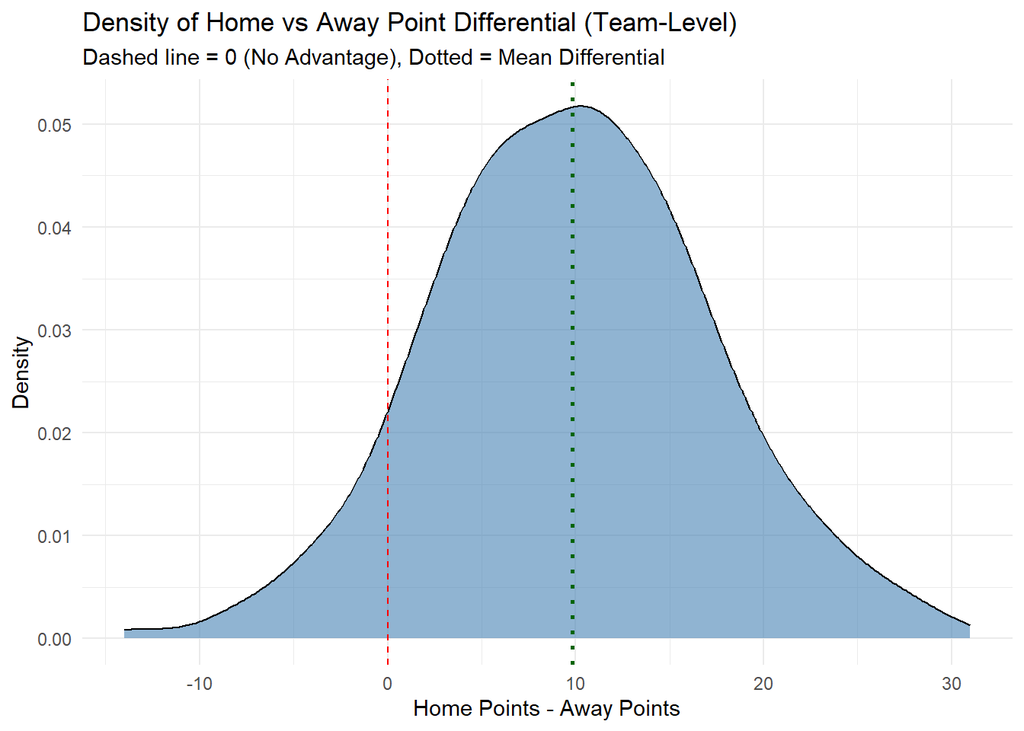

```r
ggplot(point_diff, aes(x = PointDiff)) +
  geom_density(fill = "steelblue", alpha = 0.6) +
  geom_vline(xintercept = mean(point_diff$PointDiff), color = "darkgreen", linetype = "dotted", linewidth = 1) +
  geom_vline(xintercept = 0, linetype = "dashed", color = "red") +
  labs(
    title = "Density of Home vs Away Point Differential (Team-Level)",
    subtitle = "Dashed line = 0 (No Advantage), Dotted = Mean Differential",
    x = "Home Points - Away Points",
    y = "Density"
  ) +
  theme_minimal()
```

Part 3: (R or Python) 1. Team Trajectories and Volatility • Seasonal Position Trajectories • Line plots showissng seasonal ranks for top 6 teams. • Annotate title-winning seasons. 2. Volatility Index • For each team, calculate standard deviation of final rank over all seasons. • Use a bar chart with conditional coloring (e.g., red = unstable, green = consistent). • Add text labels above each bar with exact values.

Part 3.1: Team Position Trajectories (Top 6 Teams)

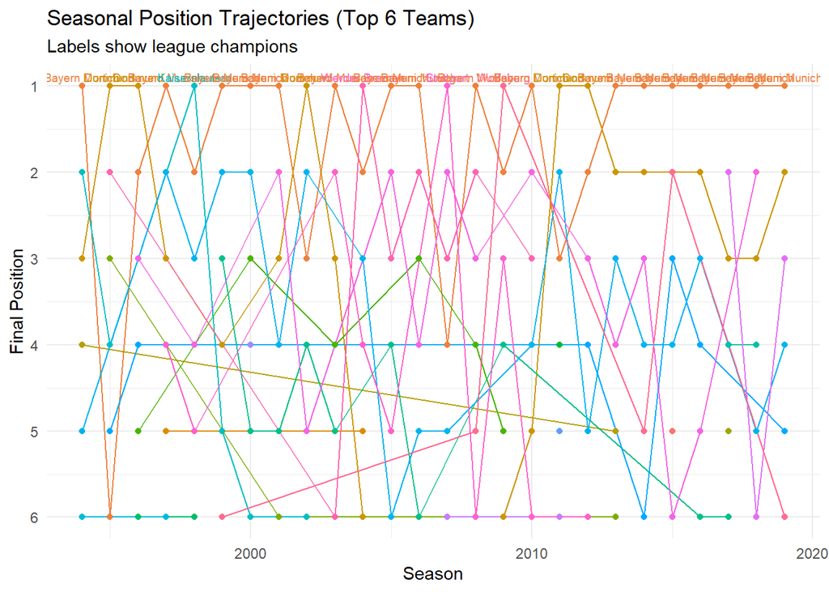

```r
top6_teams <- bundesliga2 %>%
  filter(POSITION <= 6)

top6_teams <- top6_teams %>%
  mutate(Champion = ifelse(POSITION == 1, TEAM, NA))

ggplot(top6_teams, aes(x = SEASON, y = POSITION, group = TEAM, color = TEAM)) +
  geom_line() +
  geom_point() +
  scale_y_reverse(breaks = 1:6) +
  geom_text(aes(label = Champion), vjust = -0.5, size = 2.5, na.rm = TRUE) +
  labs(
    title = "Seasonal Position Trajectories (Top 6 Teams)",
    subtitle = "Labels show league champions",
    x = "Season", y = "Final Position"
  ) +
  theme_minimal() +
  theme(legend.position = "none")
```

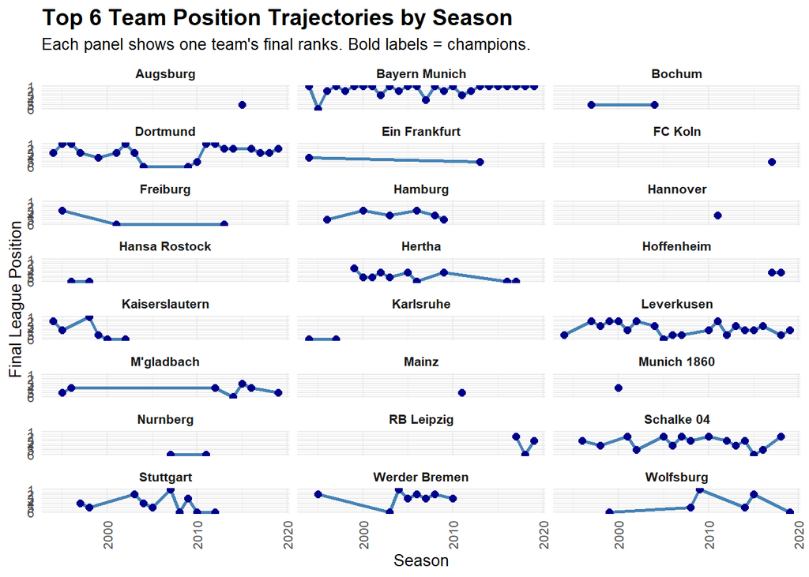

```r
top6_teams <- bundesliga2 %>%
  filter(POSITION <= 6)

top6_teams <- top6_teams %>%
  mutate(Champion = ifelse(POSITION == 1, TEAM, NA))

ggplot(top6_teams, aes(x = SEASON, y = POSITION)) +
  geom_line(aes(group = TEAM), color = "steelblue", linewidth = 1) +
  geom_point(color = "darkblue", size = 2) +
  geom_text(aes(label = Champion), vjust = -1, size = 2.5, na.rm = TRUE, fontface = "bold", color = "firebrick") +
  facet_wrap(~ TEAM, ncol = 3) +
  scale_y_reverse(breaks = 1:6) +
  labs(
    title = "Top 6 Team Position Trajectories by Season",
    subtitle = "Each panel shows one team's final ranks. Bold labels = champions.",
    x = "Season", y = "Final League Position"
  ) +
  theme_minimal(base_size = 10) +
  theme(
    axis.text.x = element_text(angle = 90, vjust = 0.5),
    strip.text = element_text(face = "bold"),
    plot.title = element_text(face = "bold", size = 14)
  )
```

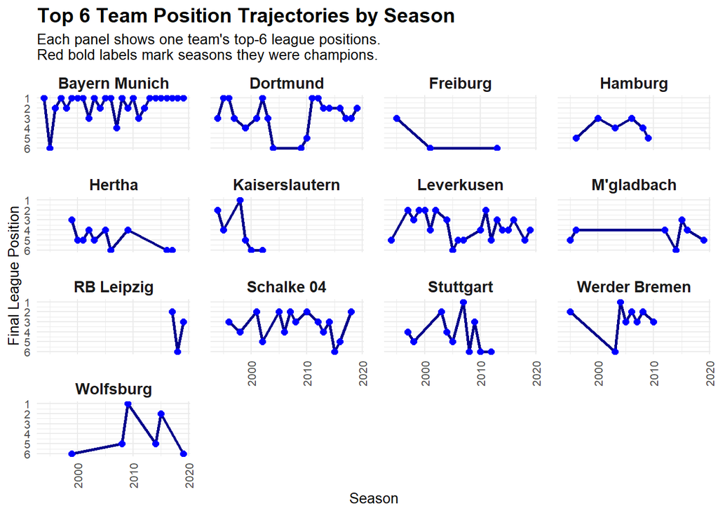

```r
library(tidyverse)

top6_teams <- bundesliga2 %>%
  filter(POSITION <= 6)

top6_teams <- top6_teams %>%
  mutate(Champion = ifelse(POSITION == 1, TEAM, NA))
top6_active <- top6_teams %>%
  count(TEAM) %>%
  filter(n > 2) %>%
  pull(TEAM)

top6_teams <- top6_teams %>%
  filter(TEAM %in% top6_active)

ggplot(top6_teams, aes(x = SEASON, y = POSITION)) +
  geom_line(color = "darkblue", linewidth = 1) +
  geom_point(color = "blue", size = 2) +
  geom_text(aes(label = Champion), vjust = -0.9, size = 2.8, fontface = "bold", color = "red", na.rm = TRUE) +
  facet_wrap(~ TEAM, ncol = 4) +
  scale_y_reverse(breaks = 1:6) +
  labs(
    title = "Top 6 Team Position Trajectories by Season",
    subtitle = "Each panel shows one team's top-6 league positions.\nRed bold labels mark seasons they were champions.",
    x = "Season", y = "Final League Position"
  ) +
  theme_minimal(base_size = 10) +
  theme(
    strip.text = element_text(face = "bold", size = 11),
    axis.text.x = element_text(angle = 90, vjust = 0.5),
    plot.title = element_text(face = "bold", size = 14),
    plot.subtitle = element_text(size = 10),
    panel.spacing = unit(1, "lines")
  )
```

Part 3.2: Volatility Index

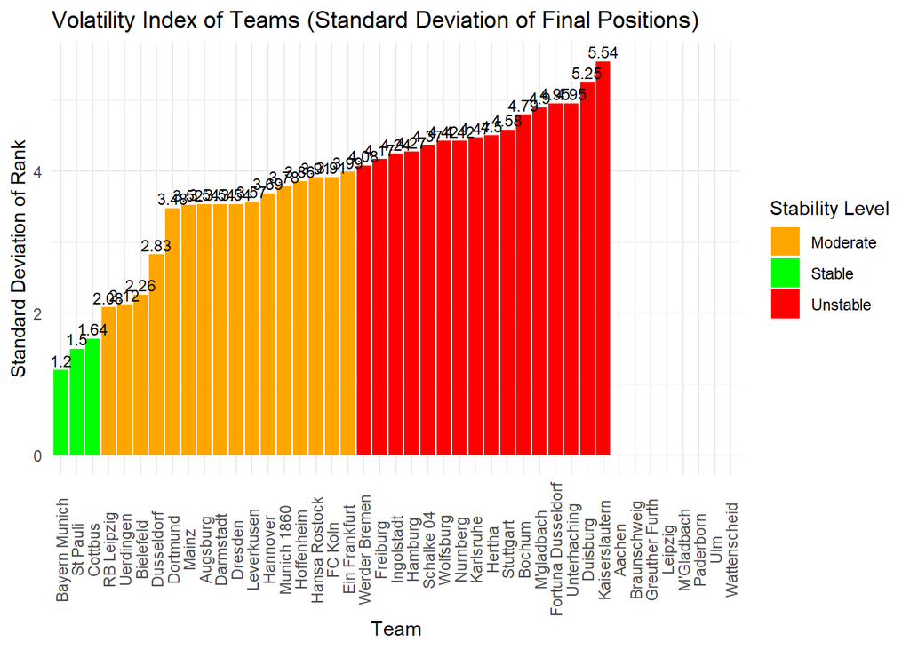

```r
volatility <- bundesliga2 %>%
  group_by(TEAM) %>%
  summarise(Volatility = sd(POSITION), .groups = "drop")

volatility <- volatility %>%
  mutate(Consistency = case_when(
    Volatility < 2 ~ "Stable",
    Volatility < 4 ~ "Moderate",
    TRUE ~ "Unstable"
  ))

color_map <- c("Stable" = "green", "Moderate" = "orange", "Unstable" = "red")

ggplot(volatility, aes(x = reorder(TEAM, Volatility), y = Volatility, fill = Consistency)) +
  geom_col() +
  geom_text(aes(label = round(Volatility, 2)), vjust = -0.3, size = 3) +
  scale_fill_manual(values = color_map) +
  labs(
    title = "Volatility Index of Teams (Standard Deviation of Final Positions)",
    x = "Team", y = "Standard Deviation of Rank",
    fill = "Stability Level"
  ) +
  theme_minimal() +
  theme(axis.text.x = element_text(angle = 90, vjust = 0.5))
```

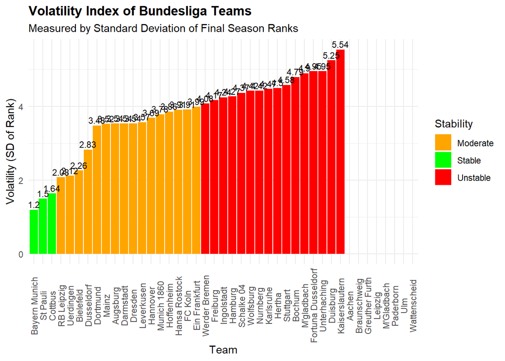

```r
volatility <- bundesliga2 %>%
  group_by(TEAM) %>%
  summarise(Volatility = sd(POSITION, na.rm = TRUE), .groups = "drop")

volatility <- volatility %>%
  mutate(Consistency = case_when(
    Volatility < 2 ~ "Stable",
    Volatility < 4 ~ "Moderate",
    TRUE ~ "Unstable"
  ))

color_map <- c("Stable" = "green", "Moderate" = "orange", "Unstable" = "red")

ggplot(volatility, aes(x = reorder(TEAM, Volatility), y = Volatility, fill = Consistency)) +
  geom_col() +
  geom_text(aes(label = round(Volatility, 2)), vjust = -0.3, size = 3) +
  scale_fill_manual(values = color_map) +
  labs(
    title = "Volatility Index of Bundesliga Teams",
    subtitle = "Measured by Standard Deviation of Final Season Ranks",
    x = "Team", y = "Volatility (SD of Rank)",
    fill = "Stability"
  ) +
  theme_minimal() +
  theme(
    axis.text.x = element_text(angle = 90, vjust = 0.5),
    plot.title = element_text(face = "bold")
  )
```

Part 4: Rivalries & Big Match Patterns (R or Python) 1. Head-to-Head Matrix for Selected Rivalries • Select 5 key rivalries more info click here . • Create a facet grid of win/draw/loss bar charts per rivalry. • Annotate biggest win margins. 2. Upset Visualizer 2 • Define “upset” as a team >8 places below beating a top-5 team. • Scatterplot of upsets: x-axis = rank difference, y-axis = goal difference. • Encode team colors; highlight and label famous upsets Note you can define top 5 by most points, most scorred goals, less consided goals.

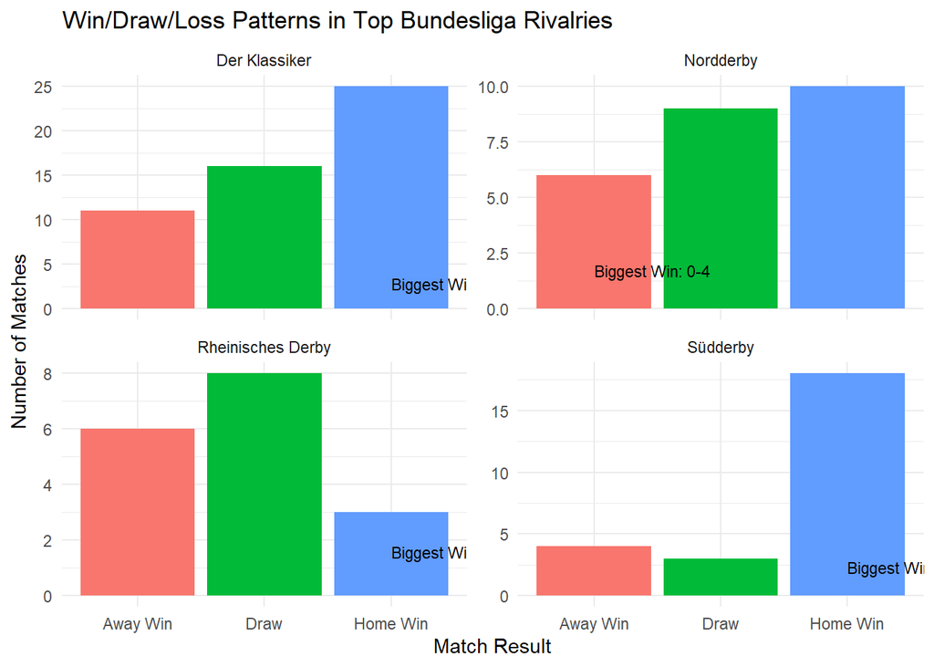

```r
rivalries <- tribble(
  ~Team1, ~Team2, ~Label,
  "Bayern Munich", "Dortmund", "Der Klassiker",
  "Dortmund", "Schalke", "Revierderby",
  "Hamburg", "Werder Bremen", "Nordderby",
  "Bayern Munich", "Stuttgart", "Südderby",
  "FC Koln", "Leverkusen", "Rheinisches Derby"
)

# Create all rivalry games
rivalry_games <- bundesliga %>%
  semi_join(rivalries, by = c("HOMETEAM" = "Team1")) %>%
  filter((AWAYTEAM %in% rivalries$Team2) |
         (HOMETEAM %in% rivalries$Team2 & AWAYTEAM %in% rivalries$Team1))

rivalry_games <- rivalry_games %>%
  mutate(
    Result = case_when(
      FTHG > FTAG ~ "Home Win",
      FTAG > FTHG ~ "Away Win",
      TRUE ~ "Draw"
    ),
    Matchup = pmap_chr(list(HOMETEAM, AWAYTEAM), function(ht, at) {
      label <- rivalries %>% filter((Team1 == ht & Team2 == at) | (Team1 == at & Team2 == ht)) %>% pull(Label)
      if (length(label) == 0) return("Other") else return(label)
    }),
    Margin = abs(FTHG - FTAG)
  ) %>%
  filter(Matchup != "Other")

biggest_wins <- rivalry_games %>%
  group_by(Matchup) %>%
  filter(Margin == max(Margin)) %>%
  slice(1) %>%
  ungroup()

ggplot(rivalry_games, aes(x = Result, fill = Result)) +
  geom_bar(show.legend = FALSE) +
  facet_wrap(~Matchup, scales = "free_y") +
  geom_text(data = biggest_wins,
            aes(label = paste0("Biggest Win: ", FTSC),
                x = Result, y = 1),
            inherit.aes = FALSE,
            hjust = 0, vjust = -0.8, size = 3, color = "black") +
  labs(
    title = "Win/Draw/Loss Patterns in Top Bundesliga Rivalries",
    x = "Match Result", y = "Number of Matches"
  ) +
  theme_minimal()
```

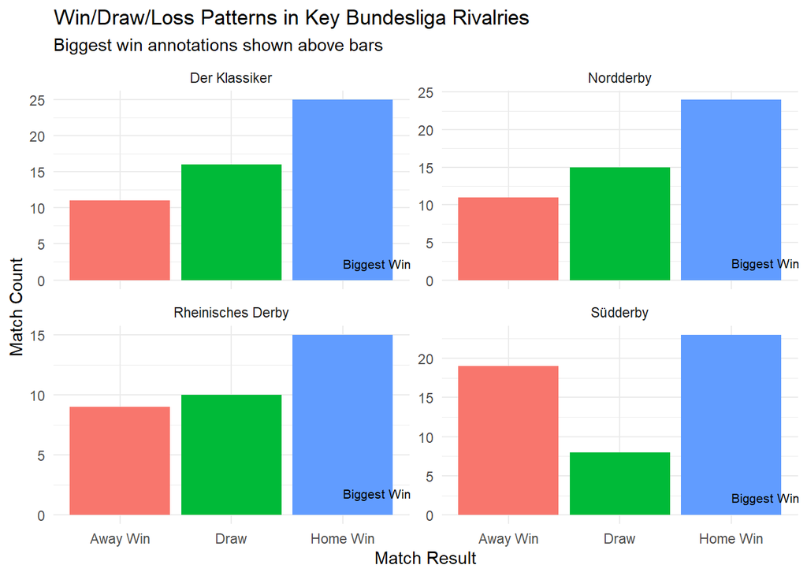

```r
rivalries <- tribble(
  ~Team1, ~Team2, ~Label,
  "Bayern Munich", "Dortmund", "Der Klassiker",
  "Dortmund", "Schalke", "Revierderby",
  "Hamburg", "Werder Bremen", "Nordderby",
  "Bayern Munich", "Stuttgart", "Südderby",
  "FC Koln", "Leverkusen", "Rheinisches Derby"
)

# Filter games that match either direction of the rivalry
rivalry_games <- bundesliga %>%
  filter(
    (paste(HOMETEAM, AWAYTEAM) %in% paste(rivalries$Team1, rivalries$Team2)) |
    (paste(HOMETEAM, AWAYTEAM) %in% paste(rivalries$Team2, rivalries$Team1))
  ) %>%
  mutate(
    Matchup = case_when(
      (HOMETEAM == "Bayern Munich" & AWAYTEAM == "Dortmund") | (HOMETEAM == "Dortmund" & AWAYTEAM == "Bayern Munich") ~ "Der Klassiker",
      (HOMETEAM == "Dortmund" & AWAYTEAM == "Schalke") | (HOMETEAM == "Schalke" & AWAYTEAM == "Dortmund") ~ "Revierderby",
      (HOMETEAM == "Hamburg" & AWAYTEAM == "Werder Bremen") | (HOMETEAM == "Werder Bremen" & AWAYTEAM == "Hamburg") ~ "Nordderby",
      (HOMETEAM == "Bayern Munich" & AWAYTEAM == "Stuttgart") | (HOMETEAM == "Stuttgart" & AWAYTEAM == "Bayern Munich") ~ "Südderby",
      (HOMETEAM == "FC Koln" & AWAYTEAM == "Leverkusen") | (HOMETEAM == "Leverkusen" & AWAYTEAM == "FC Koln") ~ "Rheinisches Derby",
      TRUE ~ NA_character_
    ),
    Result = case_when(
      FTHG > FTAG ~ "Home Win",
      FTAG > FTHG ~ "Away Win",
      TRUE ~ "Draw"
    ),
    GoalMargin = abs(FTHG - FTAG),
    ScoreLabel = paste0(FTHG, "-", FTAG)
  ) %>%
  filter(!is.na(Matchup))

# Find the biggest win per rivalry
biggest_wins <- rivalry_games %>%
  group_by(Matchup) %>%
  filter(GoalMargin == max(GoalMargin)) %>%
  slice(1) %>%
  ungroup()


ggplot(rivalry_games, aes(x = Result, fill = Result)) +
  geom_bar(show.legend = FALSE) +
  facet_wrap(~ Matchup, scales = "free_y") +
  geom_text(data = biggest_wins,
            aes(label = paste("Biggest Win:", HOMETEAM, ScoreLabel, AWAYTEAM),
                x = Result, y = 1),
            inherit.aes = FALSE,
            hjust = 0, vjust = -0.5, size = 2.8, color = "black") +
  labs(
    title = "Win/Draw/Loss Patterns in Key Bundesliga Rivalries",
    subtitle = "Biggest win annotations shown above bars",
    x = "Match Result", y = "Match Count"
  ) +
  theme_minimal()
```

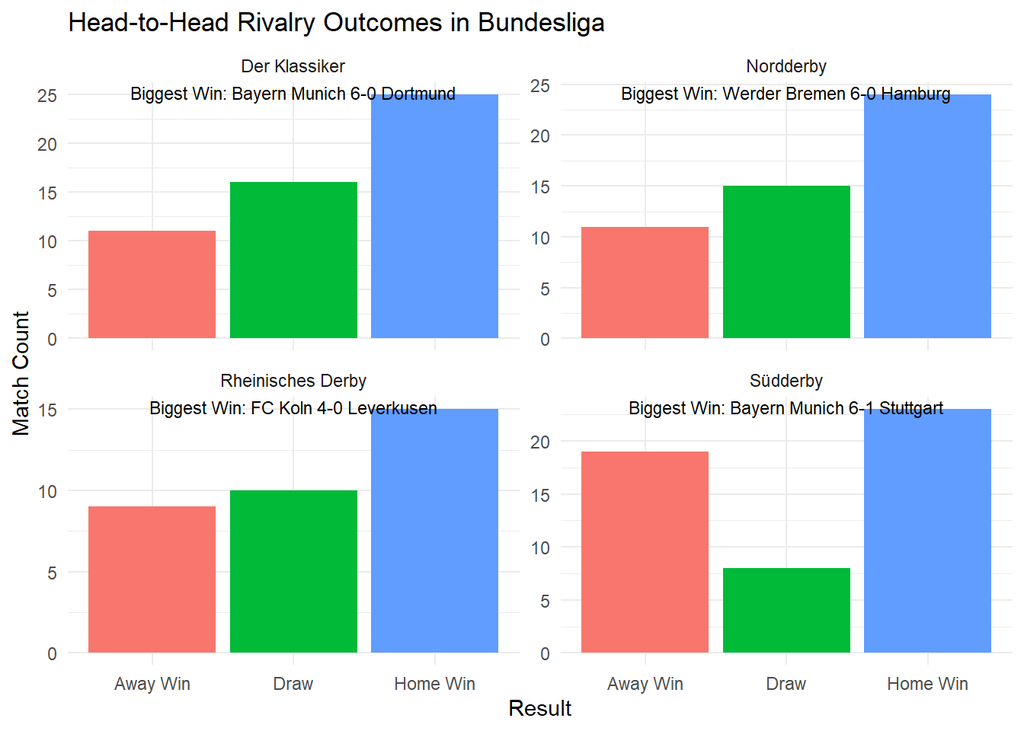

```r
library(dplyr)
library(ggplot2)

# 1. Create standard pairing columns
rivalries_std <- rivalries %>%
  mutate(
    Team_A = pmin(Team1, Team2),
    Team_B = pmax(Team1, Team2)
  ) %>%
  select(Team_A, Team_B, Label)

# 2. Create same columns for games
rivalry_games <- bundesliga %>%
  mutate(
    Team_A = pmin(HOMETEAM, AWAYTEAM),
    Team_B = pmax(HOMETEAM, AWAYTEAM)
  ) %>%
  left_join(rivalries_std, by = c("Team_A", "Team_B")) %>%
  filter(!is.na(Label))  # keep only matched rivalries

# 3. Add result and margin info
rivalry_games <- rivalry_games %>%
  mutate(
    Result = case_when(
      FTHG > FTAG ~ "Home Win",
      FTHG < FTAG ~ "Away Win",
      TRUE ~ "Draw"
    ),
    Margin = abs(FTHG - FTAG),
    Score = FTSC
  )

# 4. Summarize results
rivalry_results <- rivalry_games %>%
  group_by(Label, Result) %>%
  summarise(Count = n(), .groups = "drop")

# 5. Find biggest win per rivalry
biggest_win <- rivalry_games %>%
  group_by(Label) %>%
  filter(Margin == max(Margin)) %>%
  slice(1) %>%
  ungroup() %>%
  select(Label, HOMETEAM, AWAYTEAM, Score, Margin)

# 6. Final plot
ggplot(rivalry_results, aes(x = Result, y = Count, fill = Result)) +
  geom_bar(stat = "identity", show.legend = FALSE) +
  facet_wrap(~Label, scales = "free_y") +
  geom_text(data = biggest_win,
            aes(x = 2, y = Inf, label = paste0("Biggest Win: ", HOMETEAM, " ", Score, " ", AWAYTEAM)),
            inherit.aes = FALSE, vjust = 1.2, size = 3, color = "black") +
  labs(
    title = "Head-to-Head Rivalry Outcomes in Bundesliga",
    x = "Result", y = "Match Count"
  ) +
  theme_minimal()
```

```r
pdf("Rivalry_Head_to_Head_Charts.pdf", width = 10, height = 6)

ggplot(rivalry_results, aes(x = Result, y = Count, fill = Result)) +
  geom_bar(stat = "identity", show.legend = FALSE) +
  facet_wrap(~Label, scales = "free_y") +
  geom_text(data = biggest_win,
            aes(x = 2, y = Inf, label = paste0("Biggest Win: ", HOMETEAM, " ", Score, " ", AWAYTEAM)),
            inherit.aes = FALSE, vjust = 1.2, size = 3, color = "black") +
  labs(
    title = "Head-to-Head Rivalry Outcomes in Bundesliga",
    x = "Result", y = "Match Count"
  ) +
  theme_minimal()

dev.off()
```

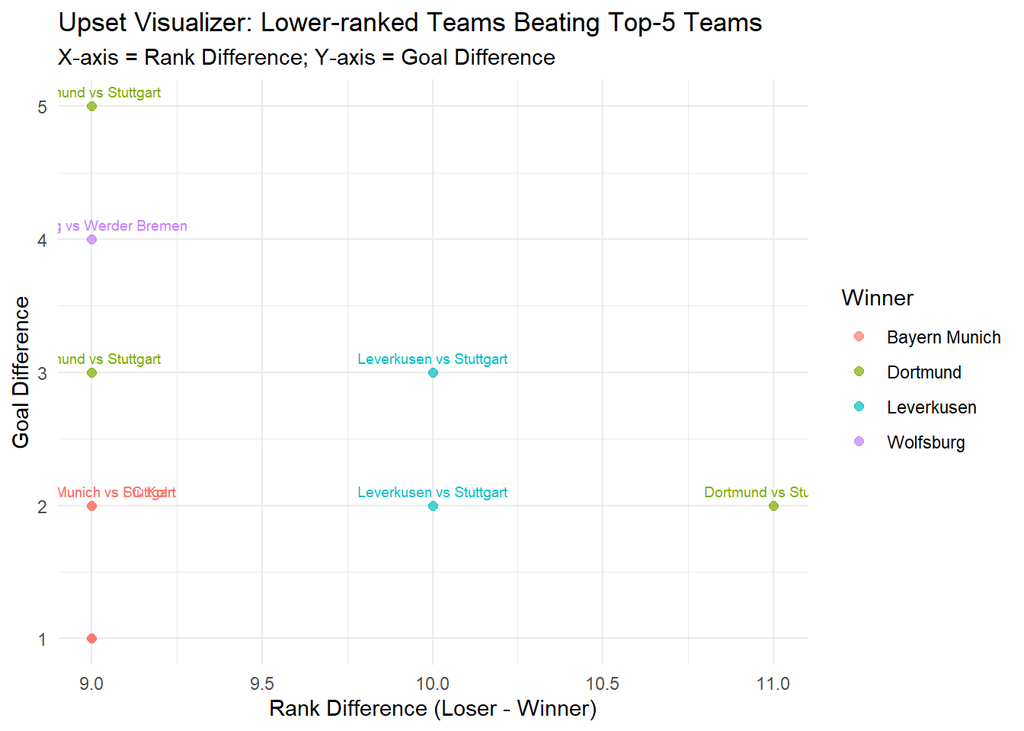

```r
# Define top 5 teams per season by goals scored
top_teams <- bundesliga2 %>%
  arrange(SEASON, desc(GF)) %>%
  group_by(SEASON) %>%
  slice_max(order_by = GF, n = 5) %>%
  mutate(Top5 = TRUE) %>%
  select(SEASON, TEAM, Top5)

# Team ranks
all_ranks <- bundesliga2 %>%
  select(SEASON, TEAM, POSITION)

upset_data <- bundesliga %>%
  left_join(all_ranks, by = c("SEASON", "HOMETEAM" = "TEAM")) %>%
  rename(HomeRank = POSITION) %>%
  left_join(all_ranks, by = c("SEASON", "AWAYTEAM" = "TEAM")) %>%
  rename(AwayRank = POSITION)

# Determine upsets
upsets <- upset_data %>%
  mutate(
    Winner = case_when(
      FTHG > FTAG ~ HOMETEAM,
      FTAG > FTHG ~ AWAYTEAM,
      TRUE ~ NA_character_
    ),
    Loser = case_when(
      FTHG > FTAG ~ AWAYTEAM,
      FTAG > FTHG ~ HOMETEAM,
      TRUE ~ NA_character_
    ),
    WinnerRank = case_when(
      FTHG > FTAG ~ HomeRank,
      FTAG > FTHG ~ AwayRank,
      TRUE ~ NA_real_
    ),
    LoserRank = case_when(
      FTHG > FTAG ~ AwayRank,
      FTAG > FTHG ~ HomeRank,
      TRUE ~ NA_real_
    ),
    GoalDiff = abs(FTHG - FTAG),
    RankDiff = LoserRank - WinnerRank
  ) %>%
  filter(!is.na(WinnerRank), !is.na(LoserRank)) %>%
  filter(RankDiff > 8)

# Keep only if loser was a top 5 team
upsets <- upsets %>%
  left_join(top_teams, by = c("SEASON", "Loser" = "TEAM")) %>%
  filter(Top5 == TRUE)

# Pick 5 most dramatic upsets
highlight_upsets <- upsets %>%
  slice_max(order_by = GoalDiff, n = 5)

# Plot
ggplot(upsets, aes(x = RankDiff, y = GoalDiff, color = Winner)) +
  geom_point(alpha = 0.7, size = 2) +
  geom_text(data = highlight_upsets,
            aes(label = paste0(Winner, " vs ", Loser)),
            vjust = -0.8, size = 2.5, show.legend = FALSE) +
  labs(
    title = "Upset Visualizer: Lower-ranked Teams Beating Top-5 Teams",
    subtitle = "X-axis = Rank Difference; Y-axis = Goal Difference",
    x = "Rank Difference (Loser - Winner)",
    y = "Goal Difference",
    color = "Winner"
  ) +
  theme_minimal()
```

Part 5: Overall performance (R and Python) • Define unique color for each team per season. For each season create horizontal bar plot using total number of points. Highlighting the winner with the unique color that you assigned to it. Save all graphs in pdf. (R) • Redo the same task in python. But instead of total points use goal difference. Use same logic for colors as in first part. (Python)

```r
library(dplyr)
library(ggplot2)

# Assign unique colors to teams
team_colors <- bundesliga2 %>%
  distinct(TEAM) %>%
  mutate(Color = sample(colors(), n(), replace = FALSE))

seasonal_data <- bundesliga2 %>%
  left_join(team_colors, by = "TEAM")

pdf("Overall_Performance_Points_R.pdf", width = 10, height = 6)

for (s in sort(unique(seasonal_data$SEASON))) {
  season_df <- filter(seasonal_data, SEASON == s)
  winner <- season_df %>% filter(POSITION == 1) %>% pull(TEAM)

  gg <- ggplot(season_df, aes(x = reorder(TEAM, POINTS), y = POINTS)) +
    geom_col(aes(fill = TEAM == winner)) +
    scale_fill_manual(values = c("gray", season_df$Color[season_df$TEAM == winner])) +
    coord_flip() +
    labs(
      title = paste("Season", s, "- Total Points per Team"),
      subtitle = paste("Winner:", winner),
      x = "Team", y = "Points"
    ) +
    theme_minimal()

  print(gg)
}

dev.off()
```

Part 6. Monte Carlo simulation. (R or Python) Use Monte Carlo simulation to predict how many goals will Bayern Munchen score for next 10 seasons. Re- peat the same for Bayer Leverkusen and Borusia Dortmund. Compare results using appropriate visualization technique. For more about monte carlo simulation click here

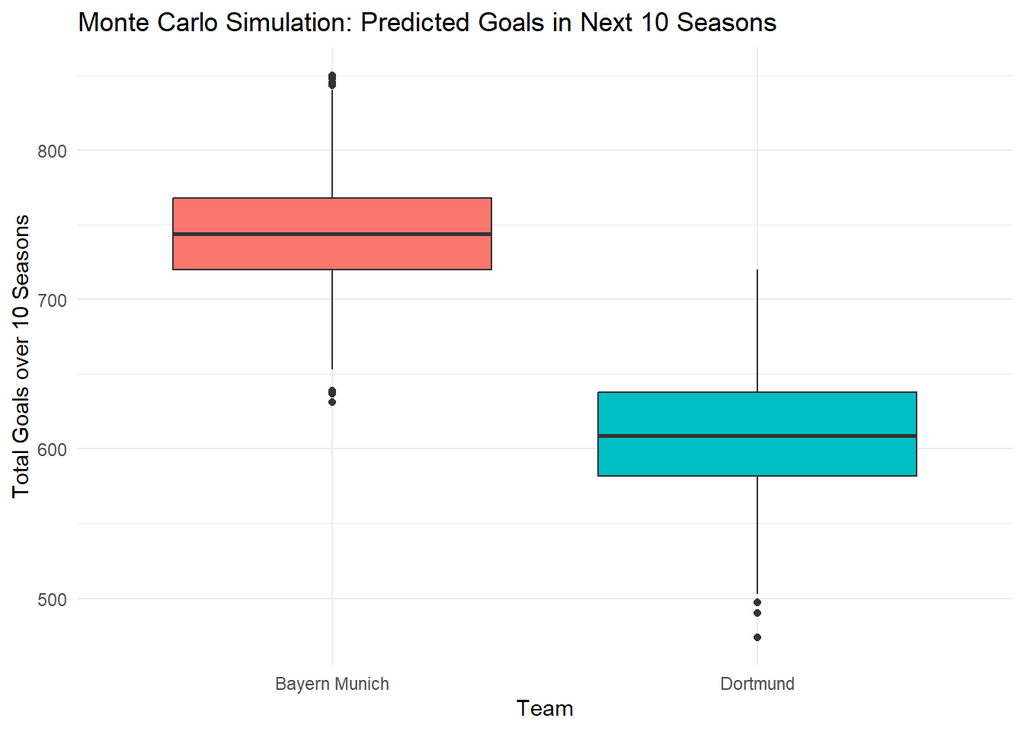

```r
library(dplyr)
library(ggplot2)
library(tidyr)

team_goals <- bundesliga %>%
  pivot_longer(cols = c(HOMETEAM, AWAYTEAM), names_to = "SIDE", values_to = "TEAM") %>%
  mutate(GOALS = ifelse(SIDE == "HOMETEAM", FTHG, FTAG)) %>%
  group_by(SEASON, TEAM) %>%
  summarise(TotalGoals = sum(GOALS), .groups = "drop")

teams <- c("Bayern Munich", "Bayer Leverkusen", "Dortmund")

selected_teams <- team_goals %>%
  filter(TEAM %in% teams)

set.seed(42)
simulations <- selected_teams %>%
  group_by(TEAM) %>%
  summarise(HistoricalGoals = list(TotalGoals), .groups = "drop") %>%
  rowwise() %>%
  mutate(
    SimulatedGoals = list(
      replicate(1000, sum(sample(HistoricalGoals, 10, replace = TRUE)))
    )
  ) %>%
  unnest(cols = c(SimulatedGoals))

simulations <- simulations %>%
  rename(Sum10Seasons = SimulatedGoals)
ggplot(simulations, aes(x = TEAM, y = Sum10Seasons, fill = TEAM)) +
  geom_boxplot() +
  labs(
    title = "Monte Carlo Simulation: Predicted Goals in Next 10 Seasons",
    y = "Total Goals over 10 Seasons", x = "Team"
  ) +
  theme_minimal() +
  theme(legend.position = "none")
```

```r
#tinytex::install_tinytex()
# to uninstall TinyTeX, run
# tinytex::uninstall_tinytex()
```